# Plotly Offline for MATLAB

**NEW: Plotly's MATLAB library v.2.2.0 now includes support for Plotly Offline.**

- Instead of saving the converted MATLAB figures to a server, your data and graphs will be saved as *html* files to your current working directory using Plotly Offline. These *html* files will contain all of the necessary dependencies to render the plot within a browser.
- When your ready to share, you can just publish them to the [Plotly Cloud](https://plot.ly/feed]) or to your company's internal [Plotly Enterprise](https://plot.ly/product/enterprise).
- To get started with Plotly Offline, [start a trial](http://purchasing.plot.ly) or contact sales@plot.ly to learn about licensing and receive a URL to download the package.

```python
import plotly as py
import publisher
%load_ext pymatbridge
```

```
Starting MATLAB on ZMQ socket ipc:///tmp/pymatbridge-836c934d-5c48-47d0-a004-b2e24259152c
Send 'exit' command to kill the server
...........MATLAB started and connected!
```

**First, update the Plotly MATLAB Library so that your version is at least v.2.2.0**

```python
%%matlab

plotlyupdate;
```

```
Your Plotly API MATLAB Library v.2.2.0 is already up to date!
```

**Next, get the offline Plotly bundle using the provided download URL:**

```python
%%matlab

%getplotlyoffline('http://purchasing.plot.ly/your_licensed_plotly_offline_url')
```

```python
%%matlab

%Success! You can generate your first offline graph
%using the 'offline' flag of fig2plotly as follows:

%>> plot(1:10); fig2plotly(gcf, 'offline', true);
```

**Once successful, Plotly deprendency bundle will be installed to your Plotly config file:**

```python
%%matlab

cd ~/.plotly/plotlyjs
ls
```

```
plotly-matlab-offline-bundle.js
```

**Now, you are ready to start using Plotly offline! All you need to do is provide the `offline` flag to `fig2plotly`**.

# Examples:

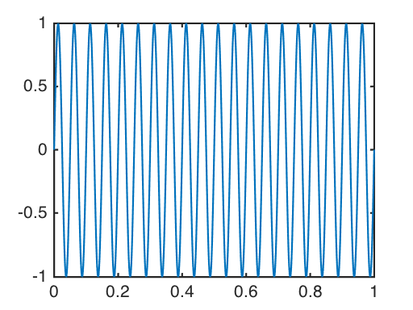

```python
%%matlab

t = linspace(0,1,1000);
plot(t, sin(2*pi*t*20), '-');


%--plotly offline--%

plotly_fig = fig2plotly(gcf, 'offline', true, 'filename', 'sine wave');
```

```python
%%matlab

plotly_fig.url
```

```
ans =

file:///Users/bronsolo/.plotly/plotlyjs/sinewave.html
```

**We can't provide the html file, but here is what it looks like once exported to Plotly:**

```python
py.tools.embed('https://plot.ly/~matlab_user_guide/6235/')
```

[interactive chart not shown]

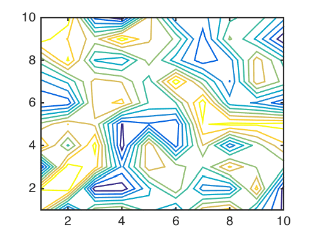

```python
%%matlab

contour(rand(10,10));

%--plotly offline--%

plotly_fig = fig2plotly(gcf, 'offline', true, 'filename', 'contour data');
```

```python
%%matlab

plotly_fig.url
```

[output not shown]

```python
py.tools.embed('https://plot.ly/~matlab_user_guide/6249')
```

[interactive chart not shown]

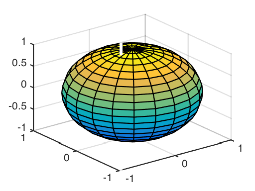

```python
%%matlab

sphere;

%--plotly offline--%

plotly_fig = fig2plotly(gcf, 'offline', true, 'filename', 'sphere');
```

```python
%%matlab

plotly_fig.url
```

```
ans =

file:///Users/bronsolo/.plotly/plotlyjs/sphere.html
```

```python
py.tools.embed('https://plot.ly/~matlab_user_guide/6265')
```

[interactive chart not shown]